# Trabajo Práctico 2, EEA

# Aclaración sobre el trabajo

# Características de la no respuesta

Hay tres tipos de no respuesta

MCAR: Missing completely at Random. La no respuesta es absolutamente aleatoria, no depende de ninguna variable. En este caso no es porblemática.

MAR: Missing at random. Hay variables que influencian la no respuesta en un marco de aleatoridad. En este caso se llevan adelante procedimientos para intentar disminuir los sesgos producidos por la misma.

MNAR: Missing Not at Random. La no respuesta no es aleatoria, dependiendo por entero de otras variables o incluso de sí misma. Es el caso más problemático de todos. Ejemplo de esto pueden ser las encuestas sobre consumo de drogas donde las mismas variables de estudio se condicionan a sí mismas generando sesgos en la no respuesta.

# La no respuesta en la EPH

```r
usu_individual_T421 %>% group_by(rol) %>% summarise(n=n(),
                                                         no_respuesta=sum(P21==(-9)),
                                                         porcentaje=no_respuesta/n,
                                                         media=mean(P21))->roles
roles[order(roles$media),]->roles
roles %>%
  knitr::kable(format = "html",
               align = "lccrr",
               caption = "No respuesta y media del ingreso según rol",
               digits = 2) %>%
  kable_material(lightable_options = c("striped", "hover") , html_font = "Cambria" )
```

No respuesta y media del ingreso según rol

| rol | n | no_respuesta | porcentaje | media |
| --- | --- | --- | --- | --- |
| Obrero NC | 4226 | 456 | 0.11 | 29969.82 |
| Otro | 130 | 38 | 0.29 | 51119.87 |
| operativos | 7808 | 1086 | 0.14 | 57395.86 |
| tecnicos | 2639 | 417 | 0.16 | 63615.40 |
| Profesional | 964 | 216 | 0.22 | 90553.58 |
| Dirección | 600 | 120 | 0.20 | 108037.37 |

```r
usu_individual_T421 %>% group_by(CH04) %>% summarise(n=n(),
                                                         no_respuesta=sum(P21==(-9)),
                                                         porcentaje=no_respuesta/n,
                                                         media=mean(P21))->sexo
sexo%>%
  knitr::kable(format = "html",
               align = "lccrr",
               caption = "No respuesta y media del ingreso según sexo",
               digits = 2) %>%
  kable_material(lightable_options = c("striped", "hover") , html_font = "Cambria" )
```

No respuesta y media del ingreso según sexo

| CH04 | n | no_respuesta | porcentaje | media |
| --- | --- | --- | --- | --- |
| 1 | 8851 | 1346 | 0.15 | 61389.40 |
| 2 | 7516 | 987 | 0.13 | 47642.96 |

```r
usu_individual_T421 %>% group_by(INTENSI) %>% summarise(n=n(),
                                                         no_respuesta=sum(P21==(-9)),
                                                         porcentaje=no_respuesta/n,
                                                         media=mean(P21))->intensidad

intensidad$INTENSI<-c("Subocupado",
                      "Ocupado",
                      "Sobreocupado",
                     "Ocupado que no trabajó en la
 semana "
)

intensidad[order(intensidad$media),]->intensidad

intensidad%>%
  knitr::kable(format = "html",
               align = "lccrr",
               caption = "No respuesta y media del ingreso según intensidad laboral",
               digits = 2) %>%
  kable_material(lightable_options = c("striped", "hover") , html_font = "Cambria" )
```

No respuesta y media del ingreso según intensidad laboral

| INTENSI | n | no_respuesta | porcentaje | media |
| --- | --- | --- | --- | --- |
| Subocupado | 1538 | 154 | 0.10 | 24610.76 |
| Ocupado | 10277 | 1550 | 0.15 | 54782.29 |
| Sobreocupado | 4169 | 574 | 0.14 | 65850.11 |
| Ocupado que no trabajó en la semana | 383 | 55 | 0.14 | 68052.22 |

```r
usu_individual_T421 %>% group_by(NIVEL_ED) %>% summarise(n=n(),
                                                         no_respuesta=sum(P21==(-9)),
                                                         porcentaje=no_respuesta/n,
                                                         media=mean(P21))->nivel_educativo

nivel_educativo$NIVEL_ED<-c("Primario incompleto",
                            "Primario completo",
                            "Secundario incompleto",
                            "Secundario completo",
                            "Universitario incompleto",
                            "Universitario completo",
                            "NS/NR")

nivel_educativo[order(nivel_educativo$media),]->nivel_educativo


nivel_educativo%>%
  knitr::kable(format = "html",
               align = "lccrr",
               caption = "No respuesta y media del ingreso según nivel educativo",
               digits = 2) %>%
  kable_material(lightable_options = c("striped", "hover") , html_font = "Cambria" )
```

No respuesta y media del ingreso según nivel educativo

| NIVEL_ED | n | no_respuesta | porcentaje | media |
| --- | --- | --- | --- | --- |
| Primario incompleto | 422 | 35 | 0.08 | 35192.39 |
| NS/NR | 52 | 9 | 0.17 | 39046.13 |
| Secundario incompleto | 2689 | 303 | 0.11 | 42021.41 |
| Primario completo | 1700 | 194 | 0.11 | 42051.98 |
| Secundario completo | 4933 | 693 | 0.14 | 52021.33 |
| Universitario incompleto | 2457 | 351 | 0.14 | 54626.04 |
| Universitario completo | 4114 | 748 | 0.18 | 75167.49 |

# Modelo líneal simple

## analizo variable a explicar

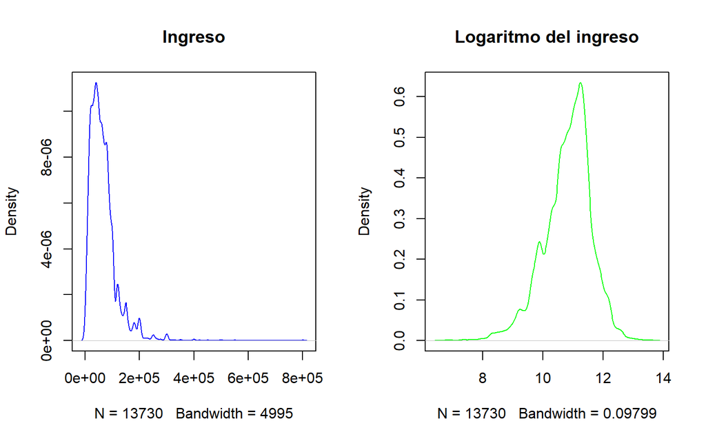

```r
usu_individual_T421 %>% filter(P21!=(-9) & P21>0)->baseAjustada
par(mfrow = c(1, 2))

# hist(baseAjustada$P21, main = "Ingreso", col = "blue")
plot(density(baseAjustada$P21), main="Ingreso", col="blue")
plot(density(log(baseAjustada$P21)), main="Logaritmo del ingreso", col="green")
```

```r
# hist(log(baseAjustada$P21), main = "Logaritmo del ingreso", col = "green")
```

```r
library(nortest)
ad.test(baseAjustada$P21)
```

```
##
##  Anderson-Darling normality test
##
## data:  baseAjustada$P21
## A = 509.52, p-value < 2.2e-16
```

```r
ad.test(log(baseAjustada$P21))
```

```
##
##  Anderson-Darling normality test
##
## data:  log(baseAjustada$P21)
## A = 94.875, p-value < 2.2e-16
```

## Hago una prueba de la regresión lineal

En primer lugar vamos a generar un modelo líneal simple. La formula será la siguiente:

$E(ingreso de ocupación principal) = β0 +β1informalidad+β2edad·rol+β3genero+β4ingreso de ocupación secundaria+$ $β5rama+β6oficio+β7aglomerado+β8intensidad de la ocupación principal$

El oficio y la categoría de informalidad se colapsaron para que no queden categorías a predecir que no se encuentren en el módelo.

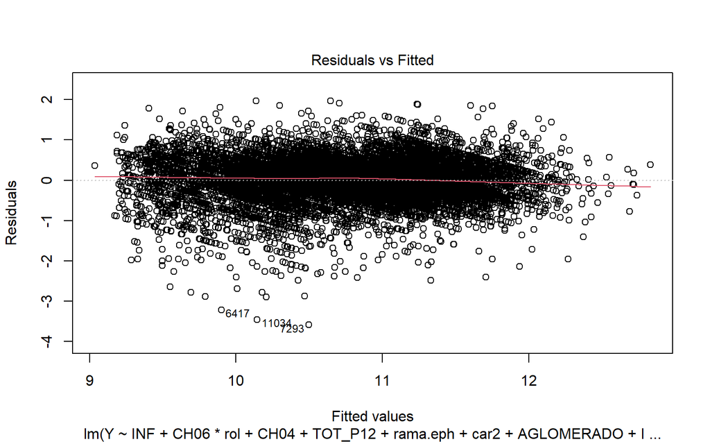

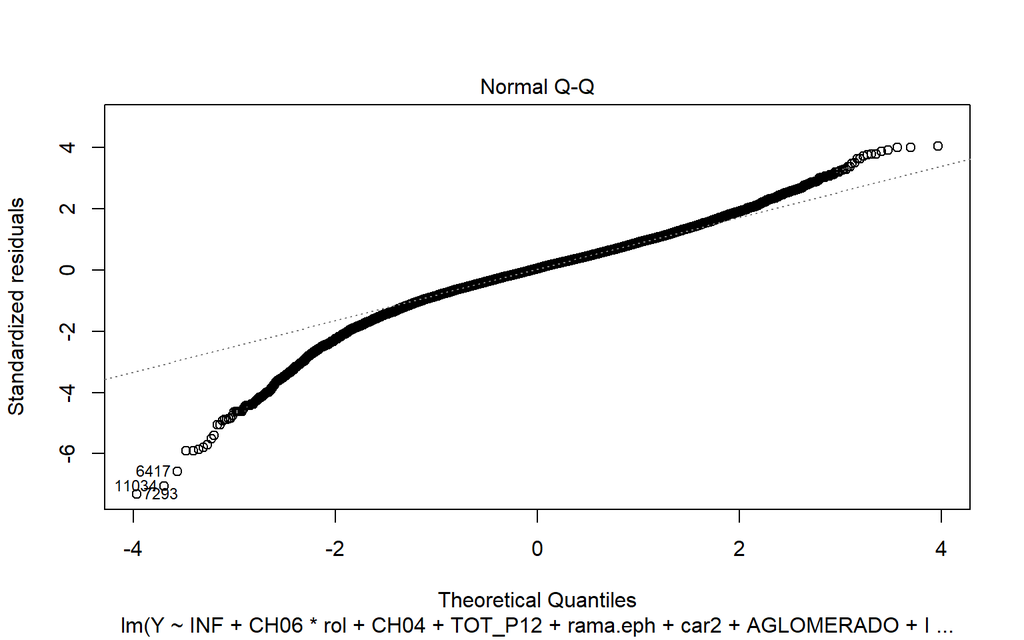

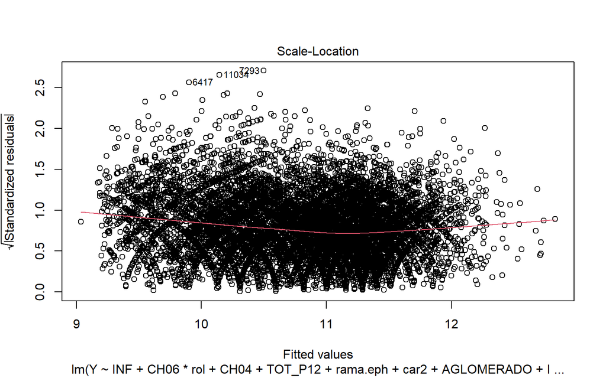

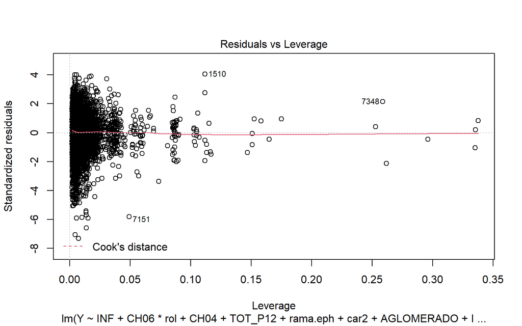

```r
baseAjustada$Y <- log(baseAjustada$P21)
modelo <- lm( Y ~ INF + CH06*rol + CH04 +TOT_P12+ rama.eph+ car2+AGLOMERADO+INTENSI, data=baseAjustada )
plot(modelo)
```

```r
library(tidymodels)
tidy_2 <- tidy(modelo, conf.int = TRUE)
tidy_2%>%
  knitr::kable(format = "html",
               align = "lccrr",
               caption = "Coeficientes modelo",
               digits = 2) %>%
  kable_material(lightable_options = c("striped", "hover") , html_font = "Cambria" )
```

Coeficientes modelo

| term | estimate | std.error | statistic | p.value | conf.low | conf.high |
| --- | --- | --- | --- | --- | --- | --- |
| (Intercept) | 11.26 | 0.33 | 33.98 | 0.00 | 10.62 | 11.91 |
| INFInformal | -0.62 | 0.01 | -57.57 | 0.00 | -0.64 | -0.60 |
| CH06 | 0.01 | 0.00 | 3.33 | 0.00 | 0.00 | 0.01 |
| rolObrero NC | -0.41 | 0.10 | -4.00 | 0.00 | -0.61 | -0.21 |
| roloperativos | -0.33 | 0.10 | -3.28 | 0.00 | -0.53 | -0.13 |
| rolOtro | -0.53 | 0.26 | -2.02 | 0.04 | -1.04 | -0.01 |
| rolProfesional | -0.12 | 0.12 | -1.00 | 0.32 | -0.37 | 0.12 |
| roltecnicos | -0.32 | 0.11 | -2.97 | 0.00 | -0.53 | -0.11 |
| CH042 | -0.15 | 0.01 | -14.27 | 0.00 | -0.17 | -0.13 |
| TOT_P12 | 0.00 | 0.00 | 0.79 | 0.43 | 0.00 | 0.00 |
| rama.eph2 | -0.12 | 0.04 | -2.74 | 0.01 | -0.21 | -0.03 |
| rama.eph3 | -0.10 | 0.05 | -2.14 | 0.03 | -0.19 | -0.01 |
| rama.eph4 | -0.15 | 0.04 | -3.59 | 0.00 | -0.24 | -0.07 |
| rama.eph5 | -0.14 | 0.05 | -2.80 | 0.01 | -0.23 | -0.04 |
| rama.eph6 | -0.06 | 0.05 | -1.32 | 0.19 | -0.15 | 0.03 |
| rama.eph7 | -0.08 | 0.04 | -1.80 | 0.07 | -0.16 | 0.01 |
| rama.eph8 | -0.16 | 0.04 | -3.68 | 0.00 | -0.24 | -0.07 |
| rama.eph9 | -0.14 | 0.05 | -2.99 | 0.00 | -0.23 | -0.05 |
| rama.eph10 | -0.18 | 0.05 | -3.80 | 0.00 | -0.27 | -0.09 |
| rama.eph11 | -0.53 | 0.07 | -8.07 | 0.00 | -0.66 | -0.40 |
| rama.eph12 | -0.27 | 0.05 | -5.65 | 0.00 | -0.36 | -0.17 |
| rama.eph13 | -0.01 | 0.06 | -0.10 | 0.92 | -0.12 | 0.11 |
| rama.eph14 | -0.08 | 0.06 | -1.36 | 0.18 | -0.18 | 0.03 |
| car210 | -0.12 | 0.31 | -0.40 | 0.69 | -0.74 | 0.49 |
| car211 | 0.10 | 0.31 | 0.32 | 0.75 | -0.52 | 0.72 |
| car220 | -0.14 | 0.31 | -0.46 | 0.65 | -0.75 | 0.47 |
| car230 | -0.24 | 0.31 | -0.77 | 0.44 | -0.85 | 0.37 |
| car231 | -0.63 | 0.32 | -1.98 | 0.05 | -1.25 | -0.01 |
| car232 | -0.23 | 0.31 | -0.73 | 0.46 | -0.85 | 0.38 |
| car233 | -0.44 | 0.34 | -1.27 | 0.20 | -1.11 | 0.24 |

[output cut: 74 more lines]

Cómo ver R2 del log

```r
summary(modelo)
```

```
##
## Call:
## lm(formula = Y ~ INF + CH06 * rol + CH04 + TOT_P12 + rama.eph +
##     car2 + AGLOMERADO + INTENSI, data = baseAjustada)
##
## Residuals:
##     Min      1Q  Median      3Q     Max
## -3.5901 -0.2634  0.0216  0.2930  1.9667
##
## Coefficients:
##                       Estimate Std. Error t value Pr(>|t|)
## (Intercept)          1.126e+01  3.315e-01  33.980  < 2e-16 ***
## INFInformal         -6.214e-01  1.079e-02 -57.570  < 2e-16 ***
## CH06                 7.071e-03  2.123e-03   3.330 0.000870 ***
## rolObrero NC        -4.124e-01  1.030e-01  -4.002 6.30e-05 ***
## roloperativos       -3.349e-01  1.020e-01  -3.284 0.001026 **
## rolOtro             -5.288e-01  2.621e-01  -2.017 0.043686 *
## rolProfesional      -1.236e-01  1.235e-01  -1.000 0.317128
## roltecnicos         -3.211e-01  1.082e-01  -2.967 0.003014 **
## CH042               -1.493e-01  1.046e-02 -14.273  < 2e-16 ***
## TOT_P12              2.194e-07  2.773e-07   0.791 0.428854
## rama.eph2           -1.217e-01  4.442e-02  -2.740 0.006160 **
## rama.eph3           -1.015e-01  4.738e-02  -2.142 0.032202 *
## rama.eph4           -1.541e-01  4.290e-02  -3.591 0.000330 ***
## rama.eph5           -1.374e-01  4.904e-02  -2.803 0.005075 **
## rama.eph6           -6.019e-02  4.556e-02  -1.321 0.186527
## rama.eph7           -7.849e-02  4.361e-02  -1.800 0.071914 .
## rama.eph8           -1.582e-01  4.296e-02  -3.684 0.000231 ***
## rama.eph9           -1.398e-01  4.681e-02  -2.988 0.002815 **
## rama.eph10          -1.764e-01  4.637e-02  -3.804 0.000143 ***
## rama.eph11          -5.287e-01  6.550e-02  -8.072 7.52e-16 ***
## rama.eph12          -2.677e-01  4.737e-02  -5.651 1.62e-08 ***
## rama.eph13          -5.593e-03  5.774e-02  -0.097 0.922843
## rama.eph14          -7.560e-02  5.574e-02  -1.356 0.175051
## car210              -1.248e-01  3.115e-01  -0.400 0.688835
## car211               1.007e-01  3.142e-01   0.321 0.748554
## car220              -1.425e-01  3.121e-01  -0.457 0.647860
## car230              -2.414e-01  3.118e-01  -0.774 0.438745
## car231              -6.266e-01  3.163e-01  -1.981 0.047625 *
## car232              -2.302e-01  3.137e-01  -0.734 0.463106
```

[output cut: 66 more lines]

```
## AGLOMERADO38         6.103e-02  3.919e-02   1.558 0.119353
## AGLOMERADO91         1.719e-01  3.841e-02   4.476 7.66e-06 ***
## AGLOMERADO93         1.927e-01  4.160e-02   4.633 3.64e-06 ***
## INTENSI              1.884e-01  7.288e-03  25.853  < 2e-16 ***
## CH06:rolObrero NC   -4.555e-03  2.222e-03  -2.050 0.040337 *
## CH06:roloperativos  -2.644e-03  2.182e-03  -1.211 0.225748
## CH06:rolOtro         5.747e-03  4.502e-03   1.277 0.201762
## CH06:rolProfesional  2.551e-03  2.668e-03   0.956 0.338982
## CH06:roltecnicos     8.144e-04  2.321e-03   0.351 0.725738
## ---
## Signif. codes:  0 '***' 0.001 '**' 0.01 '*' 0.05 '.' 0.1 ' ' 1
##
## Residual standard error: 0.4922 on 13626 degrees of freedom
## Multiple R-squared:  0.6092, Adjusted R-squared:  0.6062
## F-statistic: 206.2 on 103 and 13626 DF,  p-value: < 2.2e-16
```

```r
usu_individual_T421 %>% filter(P21==(-9))->baseImp
RL2<-function(baseRL, baseIMP){

    #se obtiene el logaritmo de la P21
    baseAjustada$Y <- log(baseAjustada$P21)
    #se genera el modelo según la categoría ocupacional, intensi y serv_domestico

      modelo <- lm( Y ~ INF + CH06*rol + CH04 +TOT_P12+ rama.eph+ car1+AGLOMERADO+INTENSI, data=baseAjustada )








# se genera la predicción a una base que tiene solo las variables que se toman en
# cuenta en el modelo y se agrega a la base original filtrada por la categoría ocupacional correspondiente
  baseImp$P21_predicho <- exp(predict(modelo, baseImp))






  retorno<-list(baseImp, modelo)



  return(retorno)


}
```